# Homework 3 of CS 422: Section 04

Diego Martin Crespo, A20432558

## Problem 1: Clustering

#### a) Data Cleanup

##### i. Attributes you would remove:

I wouldn’t use the attribute Name, since there are 66 different Names in this database. So it wouldn’t make sense to change them into factors and use them for clustering

### b) Clustering

#### i. Number of clusters needed

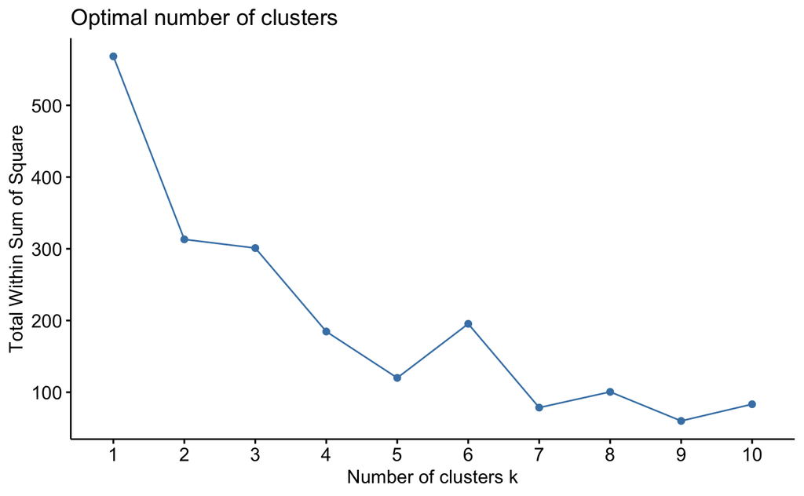

```r
m<-read.csv("file19_clean.csv", header=TRUE, sep=',', row.names = 1, stringsAsFactors = FALSE)
#mammals<- scale(m)
#mammals<-as.data.frame(mammals)
mammals<-m
library('factoextra')
library(cluster)
library(ggplot2)
library(cluster)
library(data.table)
library(dplyr)
fviz_nbclust(mammals, kmeans, method="wss")
```

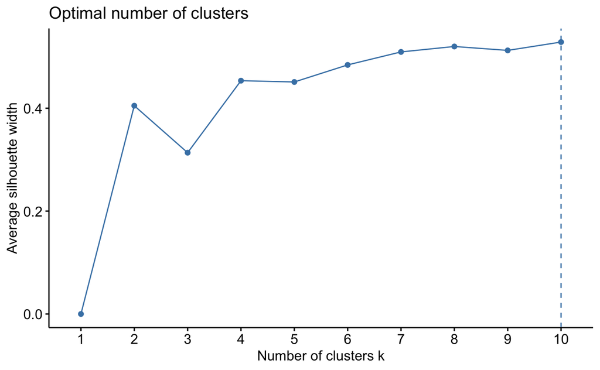

```r
fviz_nbclust(mammals, kmeans, method="silhouette")
```

The WSS method suggest using between 5 and 7 clusters, as those values are the smallest at the elbow of the graph. The silhoutte graph suggest taking beteen 7 and 10 clusters (they have the highest values and they are really close betbeen them, value 10 it is the highest). Taking into acount both methods and computational cost, it has been decided to use 7 clusters.

#### ii. Create the clusters

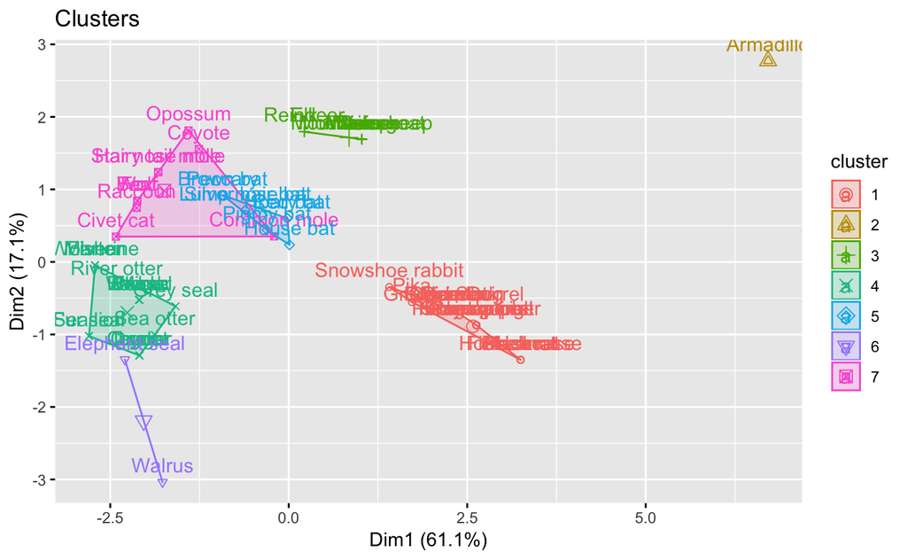

```r
k<-kmeans(mammals, centers=7, nstart=25)
fviz_cluster(k, data=mammals, main="Clusters")
```

#### iii. How many observations are in each cluster?

```r
i=1
while(i<8){
  cat("The size of cluster", i, "is", k$size[i], "\n")
  i<-i+1
}
```

```
The size of cluster 1 is 19
The size of cluster 2 is 1
The size of cluster 3 is 9
The size of cluster 4 is 17
The size of cluster 5 is 8
The size of cluster 6 is 2
The size of cluster 7 is 10
```

#### iv. What is the total SSE of the clusters?

```r
cat("The total SSE is", k$totss)
```

[output not shown]

#### v. What is the SSE of each cluster?

```r
i=1
while(i<8){
  cat("The SSE of cluster", i, "is", k$withinss[i], "\n")
  i<-i+1
}
```

```
The SSE of cluster 1 is 23.47368
The SSE of cluster 2 is 0
The SSE of cluster 3 is 1.555556
The SSE of cluster 4 is 20.70588
The SSE of cluster 5 is 6.375
The SSE of cluster 6 is 3
The SSE of cluster 7 is 21.1
```

#### vi. How are the mammals grouped in each cluster

```r
mammals$cluster<-0
for(i in 1:7){
 mammals$cluster[which(k$cluster==i)]<-i
}
summary(mammals)
```

```
       I               i               C                c                P
 Min.   :0.000   Min.   :0.000   Min.   :0.0000   Min.   :0.0000   Min.   :0.000
 1st Qu.:1.000   1st Qu.:1.000   1st Qu.:0.0000   1st Qu.:0.0000   1st Qu.:2.000
 Median :2.000   Median :3.000   Median :1.0000   Median :1.0000   Median :3.000
 Mean   :1.803   Mean   :2.379   Mean   :0.5909   Mean   :0.5455   Mean   :2.561
 3rd Qu.:3.000   3rd Qu.:3.000   3rd Qu.:1.0000   3rd Qu.:1.0000   3rd Qu.:3.000
 Max.   :5.000   Max.   :4.000   Max.   :1.0000   Max.   :1.0000   Max.   :4.000
       p               M               m            cluster
 Min.   :0.000   Min.   :0.000   Min.   :0.000   Min.   :1.000
 1st Qu.:1.000   1st Qu.:1.000   1st Qu.:2.000   1st Qu.:1.000
 Median :3.000   Median :3.000   Median :3.000   Median :4.000
 Mean   :2.424   Mean   :2.455   Mean   :2.636   Mean   :3.606
 3rd Qu.:3.000   3rd Qu.:3.000   3rd Qu.:3.000   3rd Qu.:5.000
 Max.   :4.000   Max.   :8.000   Max.   :8.000   Max.   :7.000
```

```r
for(i in 1:7){
  cluster<- mammals[ which(mammals$cluster==i),]
  print(cluster[0])
}
```

| Pika |
| --- |
| Snowshoe rabbit |
| Beaver |
| Marmot |
| Groundhog |
| Prairie Dog |
| Ground Squirrel |
| Chipmunk |
| Gray squirrel |
| Fox squirrel |

[output cut: 9 more lines]

| Armadillo |
| --- |

| Elk |
| --- |
| Deer |
| Moose |
| Reindeer |
| Antelope |
| Bison |
| Mountain goat |
| Musk ox |
| Mountain sheep |

| Marten |
| --- |
| Fisher |
| Weasel |
| Mink |
| Ferrer |
| Wolverine |
| Badger |
| Skunk |
| River otter |
| Sea otter |

[output cut: 7 more lines]

| Brown bat |
| --- |
| Silver hair bat |
| Pigmy bat |
| House bat |
| Red bat |
| Hoary bat |
| Lump nose bat |
| Peccary |

| Walrus |
| --- |
| Elephant seal |

| Opossum |
| --- |
| Hairy tail mole |
| Common mole |
| Star nose mole |
| Coyote |
| Wolf |
| Fox |
| Bear |
| Civet cat |
| Raccoon |

If we observe the names of the animals in each cluster, we see that the classification makes sense. It’s grouping animals that are similar, that eat similar food according their tooth pattern.

## Problem 2: Hierarchical clustering

First we set the seeds

```r
set.seed(1122)
animals35 <- sample_n(tbl = m[,1:8], size = 35)
```

### a) Run Hierarchical clustering

```r
l.single<-eclust(animals35, "hclust", hc_method="single")
```

```
Clustering k = 1,2,..., K.max (= 10): .. done
Bootstrapping, b = 1,2,..., B (= 100)  [one "." per sample]:
.................................................. 50
.................................................. 100
```

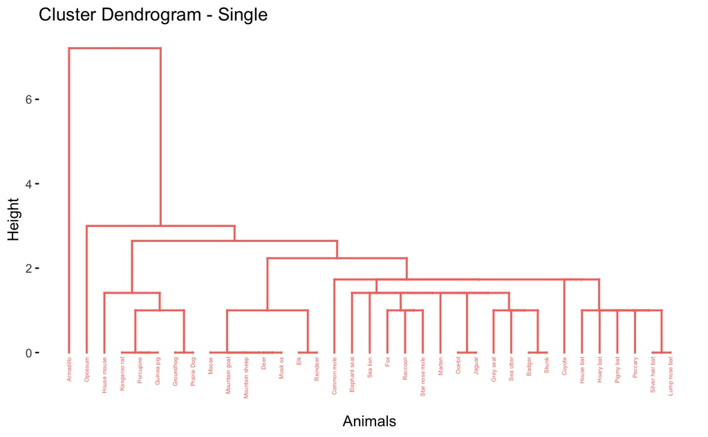

```r
fviz_dend(l.single, as.ggplot=T, cex = 0.3, main = "Cluster Dendrogram - Single", xlab = "Animals")
```

```r
l.complete<-eclust(animals35, "hclust", hc_method="complete")
```

```
Clustering k = 1,2,..., K.max (= 10): .. done
Bootstrapping, b = 1,2,..., B (= 100)  [one "." per sample]:
.................................................. 50
.................................................. 100
```

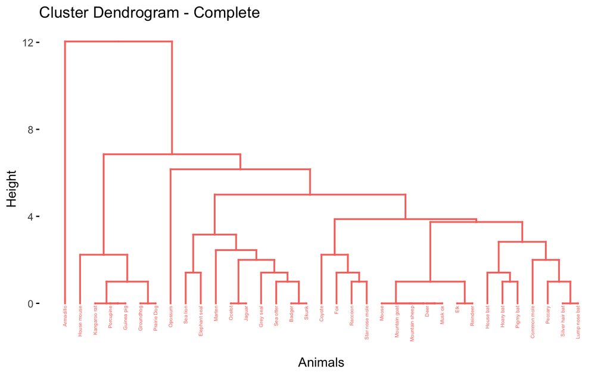

```r
fviz_dend(l.complete, show_labels=TRUE, as.ggplot=, cex = 0.3, main = "Cluster Dendrogram - Complete", xlab = "Animals")
```

```r
l.average<-eclust(animals35, "hclust", hc_method="average")
```

```
Clustering k = 1,2,..., K.max (= 10): .. done
Bootstrapping, b = 1,2,..., B (= 100)  [one "." per sample]:
.................................................. 50
.................................................. 100
```

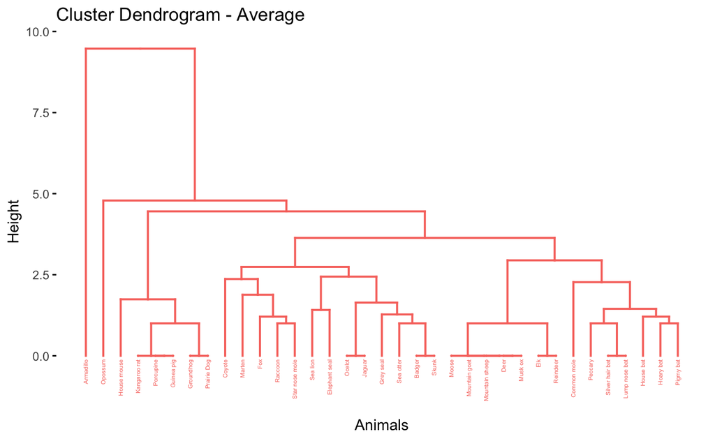

```r
fviz_dend(l.average, show_labels=TRUE, as.ggplot=T, cex = 0.3, main = "Cluster Dendrogram - Average", xlab = "Animals")
```

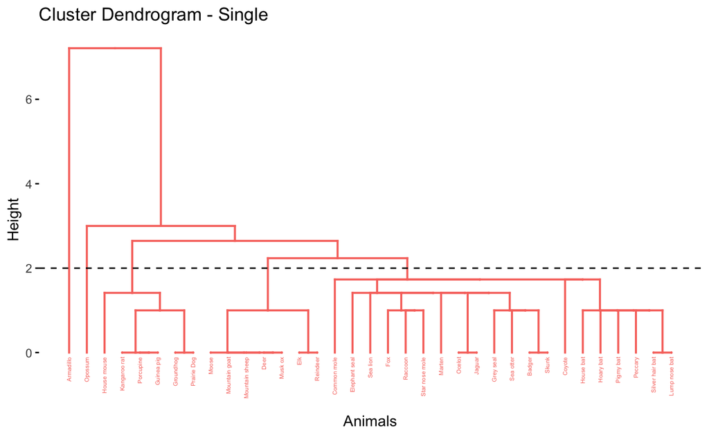

```r
fviz_dend(l.single, show_labels=TRUE, as.ggplot=T, cex = 0.3, main = "Cluster Dendrogram - Single", xlab = "Animals") + geom_hline(yintercept = 2, linetype = 2)
```

```r
cluster<-cutree(l.single, h=2)
table(cluster)
```

```
cluster
 1  2  3  4  5
20  1  6  7  1
```

### e) Now, using the number of clusters you picked in (d), re-run the hierarchical clustering using the three linkage modes

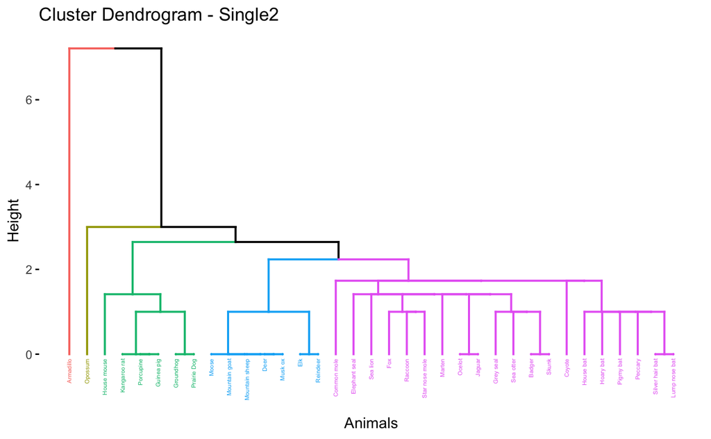

```r
single2<-factoextra::eclust(animals35, "hclust", k=5, hc_method="single")
fviz_dend(single2, show_labels=TRUE, as.ggplot=T , cex = 0.3, main = "Cluster Dendrogram - Single2", xlab = "Animals")
```

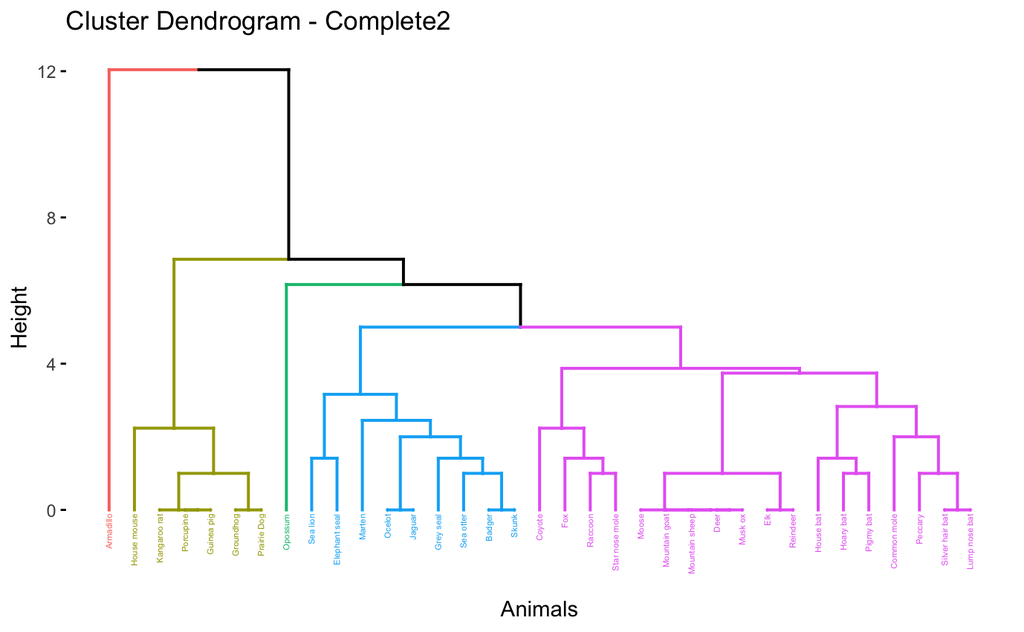

```r
complete2<-factoextra::eclust(animals35, "hclust", k=5, hc_method="complete")
fviz_dend(complete2, show_labels=TRUE, as.ggplot=T, cex = 0.3, main = "Cluster Dendrogram - Complete2", xlab = "Animals")
```

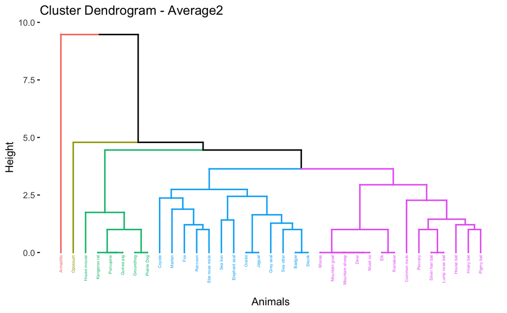

```r
average2<-factoextra::eclust(animals35, "hclust", k=5, hc_method="average")
fviz_dend(average2, show_labels=TRUE, as.ggplot=T , cex = 0.3, main = "Cluster Dendrogram - Average2", xlab = "Animals")
```

### f) For each cluster obtained by the value of k used in (e), print the Dunn and Silhouette width

```r
library(fpc)
stats_single<-cluster.stats(dist(animals35), single2$cluster)
cat('The dunn index for the Single linkage is:', stats_single$dunn)
```

```
The dunn index for the Single linkage is: 0.4472136
```

```r
cat('\nThe Silhoutte width for the Single linkage is:', stats_single$avg.silwidth)
```

```
The Silhoutte width for the Single linkage is: 0.4446204
```

```r
stats_complete<-cluster.stats(dist(animals35), complete2$cluster)
cat('\n\nThe dunn index for the Complete linkage is:', stats_complete$dunn)
```

```
The dunn index for the Complete linkage is: 0.3651484
```

```r
cat('\nThe Silhoutte width for the Complete linkage is:', stats_complete$avg.silwidth)
```

```
The Silhoutte width for the Complete linkage is: 0.3985958
```

```r
stats_avg<-cluster.stats(dist(animals35), average2$cluster)
cat('\n\nThe dunn index for the Average linkage is:', stats_avg$dunn)
```

```
The dunn index for the Average linkage is: 0.420084
```

```r
cat('\nThe Silhoutte width for the Average linkage is:', stats_avg$avg.silwidth)
```

```
The Silhoutte width for the Average linkage is: 0.4133625
```

#### g) From the three clusters in (f), which is the best cluster obtained if you consider the Dunn index and Silhoutte?

For Dunn consideration: Single is the best one since the Dunn value is higher. For Silhoutte consideration: Single is better since it has a higher Silhoutte value.

## Problem 3: K-Means and PCA

### a) Perform PCA on the dataset

```r
data <- read.csv('HTRU_2-small.csv', sep=',' , header=TRUE)
#we check that there is no missing values:
stopifnot(sum(complete.cases(data))==dim(data)[1])
#before we do the analysis we have to remove the last column, since it is the answer we are looking for and it would be overfitting
df<-data[, -9]
pca<-prcomp(scale(df))
```

#### i. How much cumulative variance is explained by the first two components?

```r
summary(pca)
```

```
Importance of components:
                          PC1    PC2    PC3     PC4     PC5     PC6     PC7     PC8
Standard deviation     2.0391 1.4581 0.8975 0.67426 0.51114 0.39844 0.14343 0.12396
Proportion of Variance 0.5197 0.2657 0.1007 0.05683 0.03266 0.01984 0.00257 0.00192
Cumulative Proportion  0.5197 0.7855 0.8862 0.94301 0.97566 0.99551 0.99808 1.00000
```

The first two components explain 0.7854 of the variance

#### ii. Plot the first two principal components

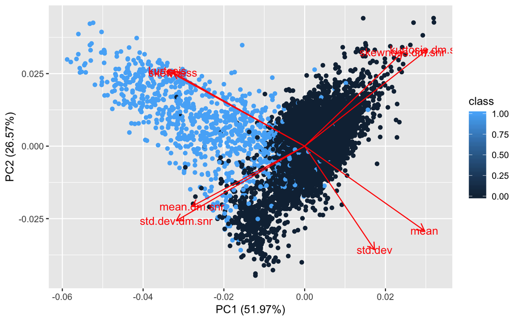

```r
library(ggfortify)
autoplot(pca, data=data, colour='class', loadings=TRUE, loadings.label=TRUE)
```

#### iii. Describe what you see with respect to the actual label of the HTRU2 dataset

The standard deviation and the mean for both the integrated profile and the DM-SNR curve seem to go together and they are opposite of the skewness and the kurtosis in both cases. They also seem to have the same gradient, more or less.

#### i. Perform K-means clustering on the dataset with k = 2.

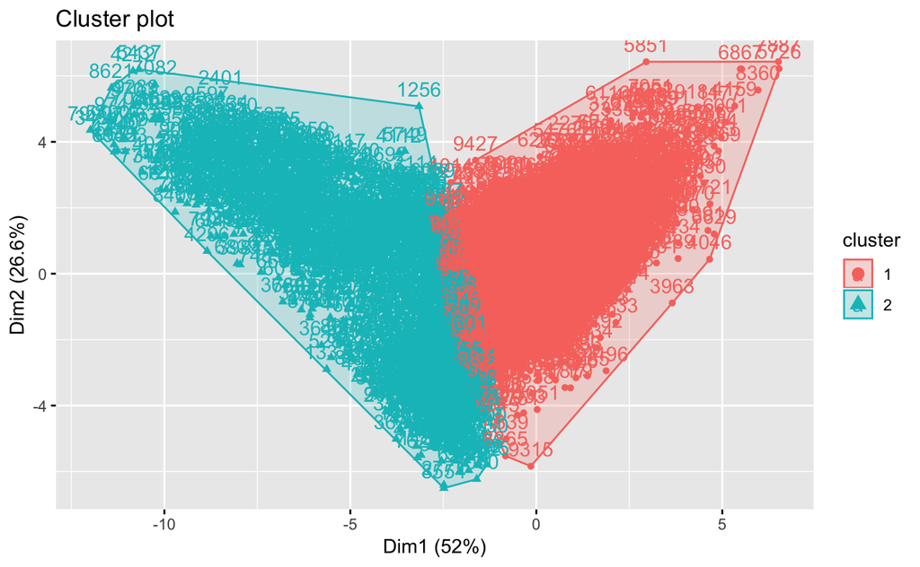

```r
k2<-kmeans(scale(df), centers=2, nstart = 25)
fviz_cluster(k2, data=scale(df))
```

#### iii. What is the distribution of the observations in each cluster?

```r
table(k2$cluster)
```

```
   1    2
8847 1153
```

#### iv. What is the distribution of the classes in the HTRU2 dataset?

```r
table(data$class)
```

```
   0    1
9041  959
```

#### vi. Get all of the observations that belong to this cluster. Then, state what is the distribution of the classes within this large cluster; i.e., how many observations in this large cluster belong to class 1 and how many belong to class 0?

```r
class_0<-k2$cluster[which(data$class==0)]
class_1<-k2$cluster[which(data$class==1)]
class_0_sum<-sum(class_0[which(class_0 ==1)])
class_1_sum<-sum(class_1[which(class_1 ==1)])
cat('The number of observations that belong to this class 0 is:', class_0_sum)
```

```
The number of observations that belong to this class 0 is: 8624
```

```r
cat('\nThe number of observations that belong to class 1 is:', class_1_sum)
```

```
The number of observations that belong to class 1 is: 223
```

#### vii. Based on the analysis above, which class (1 or 0) do you think the larger cluster represents?

The larger cluster represents class 0

#### viii. How much variance is explained by the clustering?

```r
variance<-k2$betweenss/k2$totss
cat('The variance that is explained by a cluster of 2 is:', variance)
```

```
The variance that is explained by a cluster of 2 is: 0.3586788
```

#### ix. What is the average Silhouette width of both the clusters?

```r
library(fpc)
sil<-cluster::silhouette(k2$cluster, dist(scale(df)))
a<-summary(sil)
a$avg.width
```

```
[1] 0.6006794
```

#### x. What is the average Silhouette width of both the clusters?

```r
cat('The average width for cluster 1 is:', a$clus.avg.widths[1])
```

```
The average width for cluster 1 is: 0.6592013
```

```r
cat('\nThe average width for cluster 2 is:', a$clus.avg.widths[2])
```

```
The average width for cluster 2 is: 0.1516389
```

Based on this, cluster 1 is better since the width value is higher than the average and closer to 1.

### c) Perform K-means on the result of the PCA you ran in (a).

```r
k3<-kmeans(pca$x[, 1:2], centers=2, nstart = 25)
```

#### i. Plot the clusters and comment on their shape with respect to the plots of a(ii) and b(i).

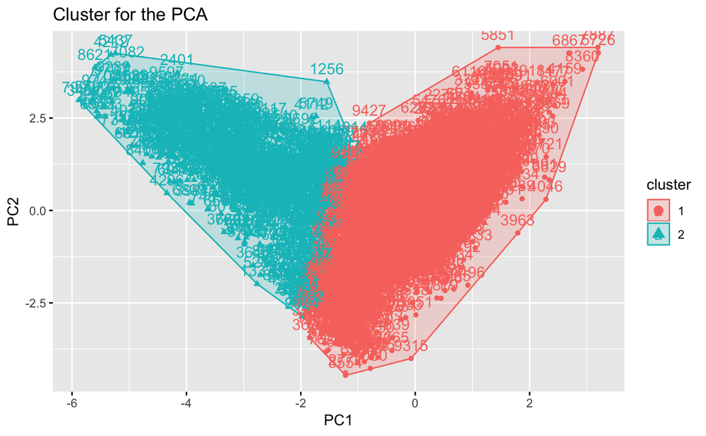

```r
fviz_cluster(k3, data=pca$x[,1:2], main="Cluster for the PCA")
```

The shape is similar to that obtained in the previous exercises

#### ii. What is the average Silhouette width of both the clusters?

```r
sil2<-cluster::silhouette(k3$cluster, dist(pca$x[,1:2]))
b<-summary(sil2)
b$avg.width
```

```
[1] 0.6826261
```

#### iii. What is the per cluster Silhouette width? Based on this, which cluster is good?

```r
cat('The average width for cluster 1 is:', b$clus.avg.widths[1])
```

```
The average width for cluster 1 is: 0.7003259
```

```r
cat('\nThe average width for cluster 2 is:', b$clus.avg.widths[2])
```

```
The average width for cluster 2 is: 0.4489076
```

In this case, cluster 1 is better since the average width is higher.

#### iv.How do the values of c(ii) and c(iii) compare with those of b(ix) and b(x), respectively?

For cluster 1 the value has improved a bit. For cluster 2 the improvement is more noticeable.